# Clustering Comparison

Consider the 2-dimensional data in the file `clusterThis.csv`

Read the data:

```r
library(tidyverse)
poly_link <- "https://raw.githubusercontent.com/reisanar/datasets/master/clusterThis.csv"
polydata <- read_csv(poly_link)
```

Take a look at the first entries in the dataset

```r
head(polydata)
```

| x | y |
| --- | --- |
| -1.545448388 | 0.69714211 |
| -0.528393243 | -0.29915289 |
| -1.086758791 | 1.36018138 |
| -0.000111512 | 1.92028747 |
| 0.388953783 | -0.05364653 |
| 0.532631272 | -0.79783816 |

### Part 1

- Plot the points in the data set using `ggplot` and the `geom_point()` function

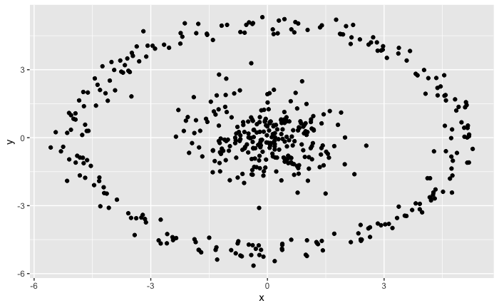

```r
ggplot(data = polydata) +
  geom_point(aes(x = x, y = y))
```

- Do you see any type of clusters/groups right away?
- Use **k-means** to try to find 2 clusters in this dataset
- Use the base R function `kmeans()` to cluster the points in 2 (two) groups. Call the clustering object `mykmeans`

```r
mykmeans <- kmeans(x = polydata, centers = 2)
```

- Explore the `mykmeans` object using the function `str()`

```r
str(mykmeans)
```

```
List of 9
 $ cluster     : int [1:500] 1 1 1 2 2 2 1 2 1 2 ...
 $ centers     : num [1:2, 1:2] -2.015 1.786 -0.456 0.26
  ..- attr(*, "dimnames")=List of 2
  .. ..$ : chr [1:2] "1" "2"
  .. ..$ : chr [1:2] "x" "y"
 $ totss       : num 6676
 $ withinss    : num [1:2] 2332 2481
 $ tot.withinss: num 4813
 $ betweenss   : num 1863
 $ size        : int [1:2] 235 265
 $ iter        : int 1
 $ ifault      : int 0
 - attr(*, "class")= chr "kmeans"
```

- Use `mykmeans$cluster` to color the points according to the cluster

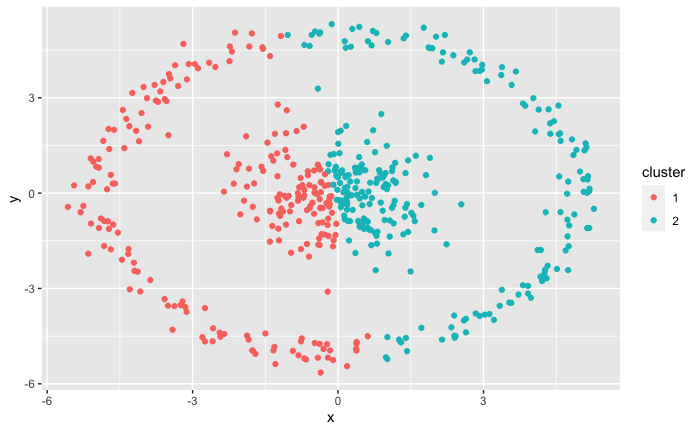

```r
polydata %>%
  mutate(cluster = factor(mykmeans$cluster)) %>%
  ggplot() +
  geom_point(aes(x = x, y = y, color = cluster))
```

### Part 2

- Use **hierarchical clustering** to try to find the groups in this dataset. Try *single linkage*. Call the clustering object `hc`

```r
# use dist() to compute the distance matrix
dis <- dist(polydata)
# use hclust() for
hc <- hclust(dis, method = "single")
```

- Explore the structure of the `hc` object

```r
str(hc)
```

```
List of 7
 $ merge      : int [1:499, 1:2] -113 -295 -83 -159 -64 -261 -371 -68 -193 -65 ...
 $ height     : num [1:499] 0.0132 0.0134 0.0176 0.0197 0.0197 ...
 $ order      : int [1:500] 277 444 279 483 293 473 362 391 460 478 ...
 $ labels     : NULL
 $ method     : chr "single"
 $ call       : language hclust(d = dis, method = "single")
 $ dist.method: chr "euclidean"
 - attr(*, "class")= chr "hclust"
```

- Cut the dendrogram tree to the proper number of clusters using the `cutree()`. Call this `comp2`

```r
comp2 <- cutree(hc, k = 2)
comp2 <- factor(comp2)
```

- Use `comp2` as the color aesthetic to plot the points with this new cluster assignment:

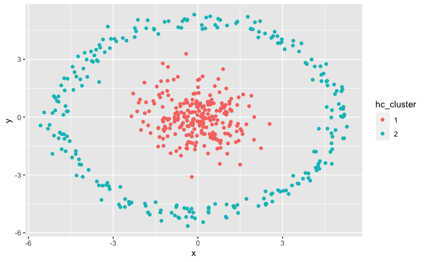

```r
polydata %>%
  mutate(hc_cluster = comp2) %>%
  ggplot() +
  geom_point(aes(x = x, y = y, color = hc_cluster))
```

### Part 3

The clustering found in Part 2 (with hierarchical clustering) might seem more natural than the one found in Part 1 (using k-means algorithm).

Can you think of a way to have the k-means method find a similar cluster structure to the one in Part 2?

```r
polar <- polydata %>%
          mutate(r = sqrt(x^2 + y^2),
                 theta = atan(y/x))
```

```r
polar
```

| x | y | r | theta |
| --- | --- | --- | --- |
| -1.545448388 | 0.697142112 | 1.6954108 | -0.423763119 |
| -0.528393243 | -0.299152891 | 0.6072000 | 0.515162216 |
| -1.086758791 | 1.360181377 | 1.7410164 | -0.896677163 |
| -0.000111512 | 1.920287471 | 1.9202875 | -1.570738256 |
| 0.388953783 | -0.053646534 | 0.3926360 | -0.137060463 |
| 0.532631272 | -0.797838160 | 0.9592923 | -0.982152602 |
| -1.837571660 | 0.769780319 | 1.9922930 | -0.396702545 |
| 0.650598453 | -0.342328601 | 0.7351648 | -0.484367625 |
| -0.624245435 | 0.686505150 | 0.9278856 | -0.832861774 |
| 0.891555027 | 2.488660267 | 2.6435393 | 1.226793506 |

[output cut: 490 more lines]

```r
polar_kmeans <- kmeans(polar[ , c("r", "theta")], centers = 2)
```

```r
str(polar_kmeans)
```

```
List of 9
 $ cluster     : int [1:500] 2 2 2 2 2 2 2 2 2 2 ...
 $ centers     : num [1:2, 1:2] 4.95508 1.1842 0.03064 -0.00852
  ..- attr(*, "dimnames")=List of 2
  .. ..$ : chr [1:2] "1" "2"
  .. ..$ : chr [1:2] "r" "theta"
 $ totss       : num 2324
 $ withinss    : num [1:2] 241 306
 $ tot.withinss: num 547
 $ betweenss   : num 1777
 $ size        : int [1:2] 253 247
 $ iter        : int 1
 $ ifault      : int 0
 - attr(*, "class")= chr "kmeans"
```

Let us see the results

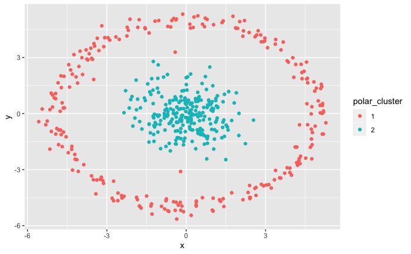

```r
polar %>%
  mutate(polar_cluster = factor(polar_kmeans$cluster)) %>%
  ggplot() +
  geom_point(aes(x = x, y = y, color = polar_cluster))
```

### Part 4

Consider the `mtcars` dataset, that contains data extracted from the 1974 Motor Trend US magazine, and comprises fuel consumption and 10 aspects of automobile design and performance for 32 automobiles (1973-74 models). Check out pictures of the different cars collected by [Mara Averick](https://twitter.com/i/moments/1001619000827228160)

```r
mtcars
```

|  | mpg | cyl | disp | hp | drat | wt | qsec | vs | am | gear | carb |
| --- | --- | --- | --- | --- | --- | --- | --- | --- | --- | --- | --- |
| Mazda RX4 | 21.0 | 6 | 160.0 | 110 | 3.90 | 2.620 | 16.46 | 0 | 1 | 4 | 4 |
| Mazda RX4 Wag | 21.0 | 6 | 160.0 | 110 | 3.90 | 2.875 | 17.02 | 0 | 1 | 4 | 4 |
| Datsun 710 | 22.8 | 4 | 108.0 | 93 | 3.85 | 2.320 | 18.61 | 1 | 1 | 4 | 1 |
| Hornet 4 Drive | 21.4 | 6 | 258.0 | 110 | 3.08 | 3.215 | 19.44 | 1 | 0 | 3 | 1 |
| Hornet Sportabout | 18.7 | 8 | 360.0 | 175 | 3.15 | 3.440 | 17.02 | 0 | 0 | 3 | 2 |
| Valiant | 18.1 | 6 | 225.0 | 105 | 2.76 | 3.460 | 20.22 | 1 | 0 | 3 | 1 |
| Duster 360 | 14.3 | 8 | 360.0 | 245 | 3.21 | 3.570 | 15.84 | 0 | 0 | 3 | 4 |
| Merc 240D | 24.4 | 4 | 146.7 | 62 | 3.69 | 3.190 | 20.00 | 1 | 0 | 4 | 2 |
| Merc 230 | 22.8 | 4 | 140.8 | 95 | 3.92 | 3.150 | 22.90 | 1 | 0 | 4 | 2 |
| Merc 280 | 19.2 | 6 | 167.6 | 123 | 3.92 | 3.440 | 18.30 | 1 | 0 | 4 | 4 |

[output cut: 22 more lines]

```r
# compute distance matrix
d_cars <- dist(mtcars)
```

Get hierarchical clustering with complete linkage method using all features available

```r
# prepare hierarchical cluster
hc_mtcars <- hclust(d_cars, method = "complete")
```

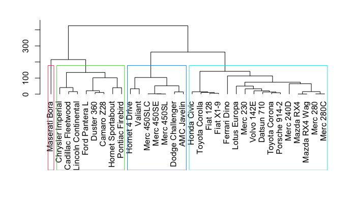

```r
# labels of the leafs at same level with hang parameter
plot(hc_mtcars, ann = FALSE, hang = -1)
rect.hclust(hc_mtcars, k = 4, border = 2:5)
```